# Q2: What kinds of building markets does New Zealand have?

k-means and hierarchical clustering of 67 districts, 2015–2025

while True: learn() · Group 8 · STAT462

**Question.** Do New Zealand’s 67 districts fall into distinct *types* of building market, and what are those types?

**Unit.** One district, profiled over 2015–2025. There is no label to predict, so this is unsupervised learning. The profiles come from `R/scripts/04_q2_profiles.R`.

```r
prof <- readRDS(derived_file("q2_profiles.rds"))
base_period <- attr(prof, "base_period")
short <- function(x) str_remove(x, " (District|City|Territory)$")
prof <- prof %>% mutate(name = short(area))
cat("Districts:", nrow(prof), "\n")
```

```
## Districts: 67
```

# 1 The district profile

Every feature is a share, a rate or a ratio, so a district’s *size* does not drive the clustering. Auckland and Kaikōura can end up together if they build in the same way. Totals are pooled over the 11 years before dividing, which keeps the ratios of small districts stable.

```r
feats <- c("share_townhouses", "share_apartments", "share_retirement",
           "real_m2", "m2_per_house", "alt_share", "nonres_area_share",
           "growth", "volatility", "per1000")

feat_info <- tribble(
  ~feature,            ~theme,       ~meaning,
  "share_townhouses",  "Type mix",   "Townhouses, flats and units as a share of new dwellings",
  "share_apartments",  "Type mix",   "Apartments as a share of new dwellings",
  "share_retirement",  "Type mix",   "Retirement village units as a share of new dwellings",
  "real_m2",           "Cost",       paste0("Real $/m² of new houses (", base_period, " dollars, CGPI-deflated)"),
  "m2_per_house",      "Cost",       "Average floor area of a new house (m²)",
  "alt_share",         "Activity",   "Alterations as a share of residential consent value",
  "nonres_area_share", "Activity",   "Non-residential share of new floor area",
  "growth",            "Dynamics",   "log(dwellings 2021–25 / dwellings 2015–19)",
  "volatility",        "Dynamics",   "SD of year-on-year log change in dwellings",
  "per1000",           "Intensity",  "New dwellings per 1,000 residents, yearly average"
)
kable(feat_info, caption = "Clustering features")
```

Clustering features

| feature | theme | meaning |
| --- | --- | --- |
| share_townhouses | Type mix | Townhouses, flats and units as a share of new dwellings |
| share_apartments | Type mix | Apartments as a share of new dwellings |
| share_retirement | Type mix | Retirement village units as a share of new dwellings |
| real_m2 | Cost | Real $/m² of new houses (2026.06 dollars, CGPI-deflated) |
| m2_per_house | Cost | Average floor area of a new house (m²) |
| alt_share | Activity | Alterations as a share of residential consent value |
| nonres_area_share | Activity | Non-residential share of new floor area |
| growth | Dynamics | log(dwellings 2021–25 / dwellings 2015–19) |
| volatility | Dynamics | SD of year-on-year log change in dwellings |
| per1000 | Intensity | New dwellings per 1,000 residents, yearly average |

**Inflation.** Cost is compared in *real* dollars: each quarter’s house value is deflated by the residential CGPI before pooling. Otherwise a district that built mostly in 2022–25 would look expensive just because it built when prices were high. The other features are counts or same-period ratios, so inflation cancels out of them.

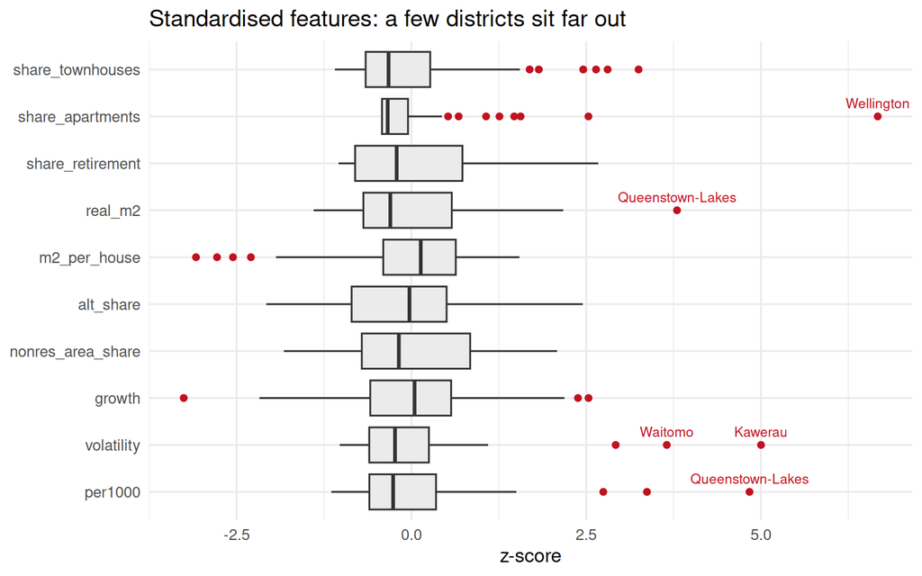

```r
prof %>%
  select(name, all_of(feats)) %>%
  mutate(across(all_of(feats), ~ as.numeric(scale(.x)))) %>%
  pivot_longer(-name, names_to = "feature", values_to = "z") %>%
  ggplot(aes(z, fct_rev(factor(feature, levels = feats)))) +
  geom_boxplot(outlier.colour = "#c1121f", fill = "grey92") +
  geom_text(data = ~ filter(.x, abs(z) > 3.5), aes(label = name),
            size = 3, vjust = -0.8, colour = "#c1121f") +
  labs(title = "Standardised features: a few districts sit far out",
       x = "z-score", y = NULL)
```

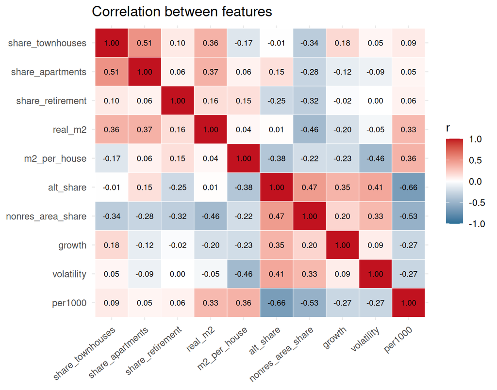

```r
cm <- cor(prof[feats])
as_tibble(cm, rownames = "a") %>%
  pivot_longer(-a, names_to = "b", values_to = "r") %>%
  mutate(a = factor(a, levels = feats), b = factor(b, levels = rev(feats))) %>%
  ggplot(aes(a, b, fill = r)) +
  geom_tile(colour = "white") +
  geom_text(aes(label = sprintf("%.2f", r)), size = 2.8) +
  scale_fill_gradient2(low = "#2a6f97", mid = "white", high = "#c1121f", limits = c(-1, 1)) +
  labs(title = "Correlation between features", x = NULL, y = NULL, fill = "r") +
  theme(axis.text.x = element_text(angle = 40, hjust = 1), legend.position = "right")
```

Distance-based methods need the features on one scale, otherwise `real_m2` (thousands) would swamp the shares (0–1). Every feature is standardised to mean 0 and SD 1.

```r
X <- scale(prof[feats])
rownames(X) <- prof$name
D <- dist(X)   # Euclidean distance between standardised profiles
```